# Risk Factor Analysis

## Outcome Variable

**Outcome Variable:** sstunted

## Predictor Variables

**Intervention Variable:** vagbrth

**Adjustment Set:**

- arm
- sex
- W_mage
- meducyrs
- feducyrs
- hhwealth_quart
- W_mhtcm
- W_mwtkg
- W_mbmi
- single
- W_nrooms
- brthmon
- W_parity
- impfloor
- delta_W_mage
- delta_meducyrs
- delta_feducyrs
- delta_hhwealth_quart
- delta_W_mhtcm
- delta_W_mwtkg
- delta_W_mbmi
- delta_single
- delta_W_nrooms
- delta_brthmon
- delta_W_parity
- delta_impfloor

## Stratifying Variables

The analysis was stratified on these variable(s):

- agecat
- studyid
- country

## Data Summary

| agecat | studyid | country | vagbrth | sstunted | n_cell | n |
| --- | --- | --- | --- | --- | --- | --- |
| Birth | CMC-V-BCS-2002 | INDIA | 0 | 0 | 10 | 92 |
| Birth | CMC-V-BCS-2002 | INDIA | 0 | 1 | 1 | 92 |
| Birth | CMC-V-BCS-2002 | INDIA | 1 | 0 | 78 | 92 |
| Birth | CMC-V-BCS-2002 | INDIA | 1 | 1 | 3 | 92 |
| Birth | IRC | INDIA | 0 | 0 | 67 | 388 |
| Birth | IRC | INDIA | 0 | 1 | 1 | 388 |
| Birth | IRC | INDIA | 1 | 0 | 305 | 388 |
| Birth | IRC | INDIA | 1 | 1 | 15 | 388 |
| Birth | JiVitA-3 | BANGLADESH | 0 | 0 | 501 | 22418 |
| Birth | JiVitA-3 | BANGLADESH | 0 | 1 | 38 | 22418 |
| Birth | JiVitA-3 | BANGLADESH | 1 | 0 | 19471 | 22418 |
| Birth | JiVitA-3 | BANGLADESH | 1 | 1 | 2408 | 22418 |
| Birth | JiVitA-4 | BANGLADESH | 0 | 0 | 73 | 2822 |
| Birth | JiVitA-4 | BANGLADESH | 0 | 1 | 3 | 2822 |
| Birth | JiVitA-4 | BANGLADESH | 1 | 0 | 2516 | 2822 |
| Birth | JiVitA-4 | BANGLADESH | 1 | 1 | 230 | 2822 |
| Birth | NIH-Crypto | BANGLADESH | 0 | 0 | 185 | 477 |
| Birth | NIH-Crypto | BANGLADESH | 0 | 1 | 1 | 477 |
| Birth | NIH-Crypto | BANGLADESH | 1 | 0 | 290 | 477 |
| Birth | NIH-Crypto | BANGLADESH | 1 | 1 | 1 | 477 |
| Birth | PROBIT | BELARUS | 0 | 0 | 1596 | 13893 |
| Birth | PROBIT | BELARUS | 0 | 1 | 1 | 13893 |
| Birth | PROBIT | BELARUS | 1 | 0 | 12292 | 13893 |
| Birth | PROBIT | BELARUS | 1 | 1 | 4 | 13893 |
| Birth | PROVIDE | BANGLADESH | 0 | 0 | 107 | 539 |
| Birth | PROVIDE | BANGLADESH | 0 | 1 | 1 | 539 |
| Birth | PROVIDE | BANGLADESH | 1 | 0 | 428 | 539 |
| Birth | PROVIDE | BANGLADESH | 1 | 1 | 3 | 539 |
| Birth | ZVITAMBO | ZIMBABWE | 0 | 0 | 1136 | 13761 |
| Birth | ZVITAMBO | ZIMBABWE | 0 | 1 | 30 | 13761 |

[output cut: 74 more lines]

The following strata were considered:

- agecat: 24 months, studyid: CMC-V-BCS-2002, country: INDIA
- agecat: 24 months, studyid: IRC, country: INDIA
- agecat: 24 months, studyid: JiVitA-3, country: BANGLADESH
- agecat: 24 months, studyid: JiVitA-4, country: BANGLADESH
- agecat: 24 months, studyid: NIH-Crypto, country: BANGLADESH
- agecat: 24 months, studyid: PROBIT, country: BELARUS
- agecat: 24 months, studyid: PROVIDE, country: BANGLADESH
- agecat: 24 months, studyid: TanzaniaChild2, country: TANZANIA, UNITED REPUBLIC OF
- agecat: 24 months, studyid: ZVITAMBO, country: ZIMBABWE
- agecat: 6 months, studyid: CMC-V-BCS-2002, country: INDIA
- agecat: 6 months, studyid: IRC, country: INDIA
- agecat: 6 months, studyid: JiVitA-3, country: BANGLADESH
- agecat: 6 months, studyid: JiVitA-4, country: BANGLADESH
- agecat: 6 months, studyid: NIH-Crypto, country: BANGLADESH
- agecat: 6 months, studyid: PROBIT, country: BELARUS
- agecat: 6 months, studyid: PROVIDE, country: BANGLADESH
- agecat: 6 months, studyid: TanzaniaChild2, country: TANZANIA, UNITED REPUBLIC OF
- agecat: 6 months, studyid: ZVITAMBO, country: ZIMBABWE
- agecat: Birth, studyid: CMC-V-BCS-2002, country: INDIA
- agecat: Birth, studyid: IRC, country: INDIA
- agecat: Birth, studyid: JiVitA-3, country: BANGLADESH
- agecat: Birth, studyid: JiVitA-4, country: BANGLADESH
- agecat: Birth, studyid: NIH-Crypto, country: BANGLADESH
- agecat: Birth, studyid: PROBIT, country: BELARUS
- agecat: Birth, studyid: PROVIDE, country: BANGLADESH
- agecat: Birth, studyid: ZVITAMBO, country: ZIMBABWE

### Dropped Strata

Some strata were dropped due to rare outcomes:

- agecat: Birth, studyid: CMC-V-BCS-2002, country: INDIA
- agecat: Birth, studyid: IRC, country: INDIA
- agecat: Birth, studyid: JiVitA-4, country: BANGLADESH
- agecat: Birth, studyid: NIH-Crypto, country: BANGLADESH
- agecat: Birth, studyid: PROBIT, country: BELARUS
- agecat: Birth, studyid: PROVIDE, country: BANGLADESH
- agecat: 6 months, studyid: CMC-V-BCS-2002, country: INDIA
- agecat: 6 months, studyid: NIH-Crypto, country: BANGLADESH
- agecat: 6 months, studyid: PROVIDE, country: BANGLADESH
- agecat: 6 months, studyid: TanzaniaChild2, country: TANZANIA, UNITED REPUBLIC OF
- agecat: 24 months, studyid: IRC, country: INDIA
- agecat: 24 months, studyid: TanzaniaChild2, country: TANZANIA, UNITED REPUBLIC OF

## Methods Detail

We’re interested in the causal parameters $E[Y_a]$ for all values of $a \in \mathcal{A}$. These parameters represent the mean outcome if, possibly contrary to fact, we intervened to set all units to have $A=a$. Under the randomization and positivity assumptions, these are identified by the statistical parameters $\psi_a=E_W[E_{Y|A,W}(Y|A=a,W)]$. In addition, we’re interested in the mean of $Y$, $E[Y]$ under no intervention (the observed mean). We will estimate these parameters by using SuperLearner to fit the relevant likelihood factors – $E_{Y|A,W}(Y|A=a,W)$ and $p(A=a|W)$, and then updating our likelihood fit using a joint TMLE.

For unadjusted analyses ($W=\{\}$), initial likelihoods were estimated using Lrnr_glm to estimate the simple $E(Y|A)$ and Lrnr_mean to estimate $p(A)$. For adjusted analyses, a small library containing Lrnr_glmnet, Lrnr_xgboost, and Lrnr_mean was used.

Having estimated these parameters, we will then use the delta method to estimate relative risks and attributable risks relative to a prespecified baseline level of $A$.

# Results Detail

## Results Plots

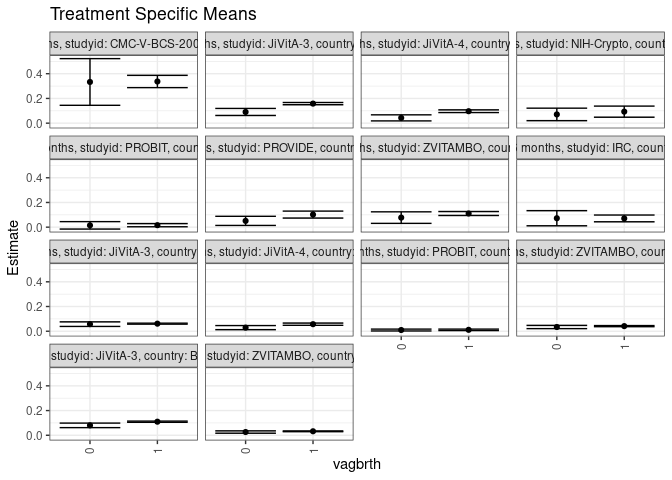

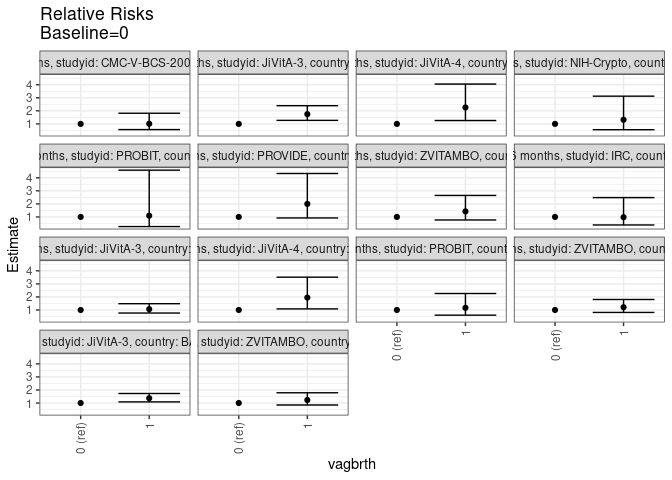

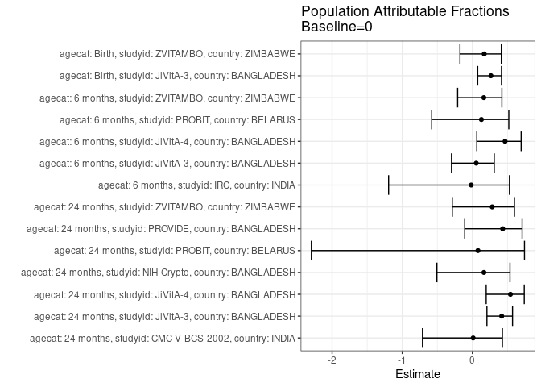

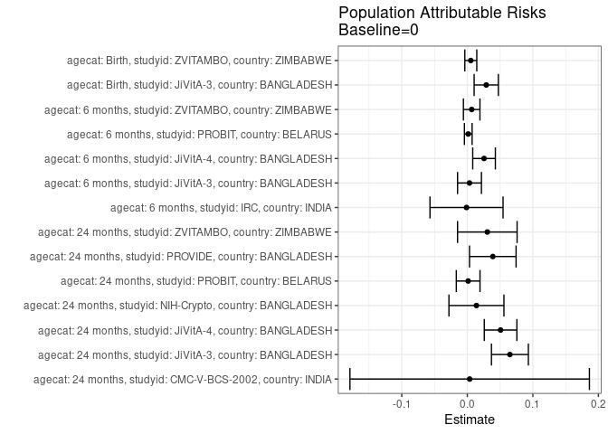

## Results Table

### Parameter: TSM

| agecat | studyid | country | intervention_level | baseline_level | estimate | ci_lower | ci_upper |
| --- | --- | --- | --- | --- | --- | --- | --- |
| Birth | JiVitA-3 | BANGLADESH | 0 | NA | 0.0802303 | 0.0618421 | 0.0986184 |
| Birth | JiVitA-3 | BANGLADESH | 1 | NA | 0.1098560 | 0.1052184 | 0.1144936 |
| Birth | ZVITAMBO | ZIMBABWE | 0 | NA | 0.0262209 | 0.0167892 | 0.0356527 |
| Birth | ZVITAMBO | ZIMBABWE | 1 | NA | 0.0322653 | 0.0291723 | 0.0353583 |
| 6 months | IRC | INDIA | 0 | NA | 0.0724638 | 0.0112169 | 0.1337106 |
| 6 months | IRC | INDIA | 1 | NA | 0.0710059 | 0.0435916 | 0.0984202 |
| 6 months | JiVitA-3 | BANGLADESH | 0 | NA | 0.0573873 | 0.0389559 | 0.0758187 |
| 6 months | JiVitA-3 | BANGLADESH | 1 | NA | 0.0611717 | 0.0571717 | 0.0651717 |
| 6 months | JiVitA-4 | BANGLADESH | 0 | NA | 0.0292587 | 0.0126215 | 0.0458959 |
| 6 months | JiVitA-4 | BANGLADESH | 1 | NA | 0.0570597 | 0.0480096 | 0.0661099 |
| 6 months | PROBIT | BELARUS | 0 | NA | 0.0097888 | 0.0021843 | 0.0173934 |
| 6 months | PROBIT | BELARUS | 1 | NA | 0.0114224 | 0.0055053 | 0.0173394 |
| 6 months | ZVITAMBO | ZIMBABWE | 0 | NA | 0.0341590 | 0.0210814 | 0.0472365 |
| 6 months | ZVITAMBO | ZIMBABWE | 1 | NA | 0.0413760 | 0.0369722 | 0.0457797 |
| 24 months | CMC-V-BCS-2002 | INDIA | 0 | NA | 0.3333333 | 0.1444810 | 0.5221856 |
| 24 months | CMC-V-BCS-2002 | INDIA | 1 | NA | 0.3371758 | 0.2873681 | 0.3869835 |
| 24 months | JiVitA-3 | BANGLADESH | 0 | NA | 0.0905420 | 0.0620827 | 0.1190013 |
| 24 months | JiVitA-3 | BANGLADESH | 1 | NA | 0.1580596 | 0.1490548 | 0.1670645 |
| 24 months | JiVitA-4 | BANGLADESH | 0 | NA | 0.0427801 | 0.0183531 | 0.0672071 |
| 24 months | JiVitA-4 | BANGLADESH | 1 | NA | 0.0966322 | 0.0857094 | 0.1075550 |
| 24 months | NIH-Crypto | BANGLADESH | 0 | NA | 0.0707071 | 0.0201159 | 0.1212983 |
| 24 months | NIH-Crypto | BANGLADESH | 1 | NA | 0.0931677 | 0.0481827 | 0.1381527 |
| 24 months | PROBIT | BELARUS | 0 | NA | 0.0148305 | -0.0151878 | 0.0448488 |
| 24 months | PROBIT | BELARUS | 1 | NA | 0.0162784 | 0.0035356 | 0.0290213 |
| 24 months | PROVIDE | BANGLADESH | 0 | NA | 0.0510949 | 0.0141917 | 0.0879981 |
| 24 months | PROVIDE | BANGLADESH | 1 | NA | 0.1020408 | 0.0737647 | 0.1303170 |
| 24 months | ZVITAMBO | ZIMBABWE | 0 | NA | 0.0775673 | 0.0309166 | 0.1242179 |
| 24 months | ZVITAMBO | ZIMBABWE | 1 | NA | 0.1107467 | 0.0947851 | 0.1267083 |

### Parameter: E(Y)

| agecat | studyid | country | intervention_level | baseline_level | estimate | ci_lower | ci_upper |
| --- | --- | --- | --- | --- | --- | --- | --- |
| Birth | JiVitA-3 | BANGLADESH | NA | NA | 0.1091088 | 0.1045539 | 0.1136636 |
| Birth | ZVITAMBO | ZIMBABWE | NA | NA | 0.0315384 | 0.0286183 | 0.0344585 |
| 6 months | IRC | INDIA | NA | NA | 0.0712531 | 0.0462303 | 0.0962759 |
| 6 months | JiVitA-3 | BANGLADESH | NA | NA | 0.0607220 | 0.0568736 | 0.0645704 |
| 6 months | JiVitA-4 | BANGLADESH | NA | NA | 0.0547878 | 0.0463432 | 0.0632323 |
| 6 months | PROBIT | BELARUS | NA | NA | 0.0112310 | 0.0054733 | 0.0169886 |
| 6 months | ZVITAMBO | ZIMBABWE | NA | NA | 0.0408092 | 0.0366277 | 0.0449907 |
| 24 months | CMC-V-BCS-2002 | INDIA | NA | NA | 0.3369272 | 0.2887662 | 0.3850883 |
| 24 months | JiVitA-3 | BANGLADESH | NA | NA | 0.1555219 | 0.1467695 | 0.1642743 |
| 24 months | JiVitA-4 | BANGLADESH | NA | NA | 0.0935323 | 0.0832327 | 0.1038320 |
| 24 months | NIH-Crypto | BANGLADESH | NA | NA | 0.0846154 | 0.0507212 | 0.1185095 |
| 24 months | PROBIT | BELARUS | NA | NA | 0.0161090 | 0.0017796 | 0.0304385 |
| 24 months | PROVIDE | BANGLADESH | NA | NA | 0.0899654 | 0.0666186 | 0.1133122 |
| 24 months | ZVITAMBO | ZIMBABWE | NA | NA | 0.1080914 | 0.0929623 | 0.1232206 |

### Parameter: RR

| agecat | studyid | country | intervention_level | baseline_level | estimate | ci_lower | ci_upper |
| --- | --- | --- | --- | --- | --- | --- | --- |
| Birth | JiVitA-3 | BANGLADESH | 0 | 0 | 1.0000000 | 1.0000000 | 1.000000 |
| Birth | JiVitA-3 | BANGLADESH | 1 | 0 | 1.3692585 | 1.0845126 | 1.728766 |
| Birth | ZVITAMBO | ZIMBABWE | 0 | 0 | 1.0000000 | 1.0000000 | 1.000000 |
| Birth | ZVITAMBO | ZIMBABWE | 1 | 0 | 1.2305167 | 0.8480895 | 1.785391 |
| 6 months | IRC | INDIA | 0 | 0 | 1.0000000 | 1.0000000 | 1.000000 |
| 6 months | IRC | INDIA | 1 | 0 | 0.9798817 | 0.3869206 | 2.481564 |
| 6 months | JiVitA-3 | BANGLADESH | 0 | 0 | 1.0000000 | 1.0000000 | 1.000000 |
| 6 months | JiVitA-3 | BANGLADESH | 1 | 0 | 1.0659452 | 0.7667399 | 1.481910 |
| 6 months | JiVitA-4 | BANGLADESH | 0 | 0 | 1.0000000 | 1.0000000 | 1.000000 |
| 6 months | JiVitA-4 | BANGLADESH | 1 | 0 | 1.9501801 | 1.0820172 | 3.514919 |
| 6 months | PROBIT | BELARUS | 0 | 0 | 1.0000000 | 1.0000000 | 1.000000 |
| 6 months | PROBIT | BELARUS | 1 | 0 | 1.1668753 | 0.6019193 | 2.262094 |
| 6 months | ZVITAMBO | ZIMBABWE | 0 | 0 | 1.0000000 | 1.0000000 | 1.000000 |
| 6 months | ZVITAMBO | ZIMBABWE | 1 | 0 | 1.2112777 | 0.8140487 | 1.802342 |
| 24 months | CMC-V-BCS-2002 | INDIA | 0 | 0 | 1.0000000 | 1.0000000 | 1.000000 |
| 24 months | CMC-V-BCS-2002 | INDIA | 1 | 0 | 1.0115274 | 0.5632472 | 1.816587 |
| 24 months | JiVitA-3 | BANGLADESH | 0 | 0 | 1.0000000 | 1.0000000 | 1.000000 |
| 24 months | JiVitA-3 | BANGLADESH | 1 | 0 | 1.7457043 | 1.2716533 | 2.396473 |
| 24 months | JiVitA-4 | BANGLADESH | 0 | 0 | 1.0000000 | 1.0000000 | 1.000000 |
| 24 months | JiVitA-4 | BANGLADESH | 1 | 0 | 2.2588123 | 1.2589754 | 4.052687 |
| 24 months | NIH-Crypto | BANGLADESH | 0 | 0 | 1.0000000 | 1.0000000 | 1.000000 |
| 24 months | NIH-Crypto | BANGLADESH | 1 | 0 | 1.3176575 | 0.5558122 | 3.123755 |
| 24 months | PROBIT | BELARUS | 0 | 0 | 1.0000000 | 1.0000000 | 1.000000 |
| 24 months | PROBIT | BELARUS | 1 | 0 | 1.0976304 | 0.2628358 | 4.583821 |
| 24 months | PROVIDE | BANGLADESH | 0 | 0 | 1.0000000 | 1.0000000 | 1.000000 |
| 24 months | PROVIDE | BANGLADESH | 1 | 0 | 1.9970845 | 0.9213693 | 4.328717 |
| 24 months | ZVITAMBO | ZIMBABWE | 0 | 0 | 1.0000000 | 1.0000000 | 1.000000 |
| 24 months | ZVITAMBO | ZIMBABWE | 1 | 0 | 1.4277506 | 0.7694053 | 2.649412 |

### Parameter: PAR

| agecat | studyid | country | intervention_level | baseline_level | estimate | ci_lower | ci_upper |
| --- | --- | --- | --- | --- | --- | --- | --- |
| Birth | JiVitA-3 | BANGLADESH | 0 | NA | 0.0288785 | 0.0104036 | 0.0473533 |
| Birth | ZVITAMBO | ZIMBABWE | 0 | NA | 0.0053175 | -0.0038101 | 0.0144450 |
| 6 months | IRC | INDIA | 0 | NA | -0.0012107 | -0.0569370 | 0.0545156 |
| 6 months | JiVitA-3 | BANGLADESH | 0 | NA | 0.0033347 | -0.0148702 | 0.0215395 |
| 6 months | JiVitA-4 | BANGLADESH | 0 | NA | 0.0255291 | 0.0082551 | 0.0428030 |
| 6 months | PROBIT | BELARUS | 0 | NA | 0.0014421 | -0.0044423 | 0.0073266 |
| 6 months | ZVITAMBO | ZIMBABWE | 0 | NA | 0.0066503 | -0.0059589 | 0.0192594 |
| 24 months | CMC-V-BCS-2002 | INDIA | 0 | NA | 0.0035939 | -0.1790816 | 0.1862693 |
| 24 months | JiVitA-3 | BANGLADESH | 0 | NA | 0.0649799 | 0.0368266 | 0.0931332 |
| 24 months | JiVitA-4 | BANGLADESH | 0 | NA | 0.0507522 | 0.0258702 | 0.0756343 |
| 24 months | NIH-Crypto | BANGLADESH | 0 | NA | 0.0139083 | -0.0280339 | 0.0558505 |
| 24 months | PROBIT | BELARUS | 0 | NA | 0.0012785 | -0.0168090 | 0.0193660 |
| 24 months | PROVIDE | BANGLADESH | 0 | NA | 0.0388705 | 0.0033552 | 0.0743858 |
| 24 months | ZVITAMBO | ZIMBABWE | 0 | NA | 0.0305242 | -0.0149017 | 0.0759501 |

### Parameter: PAF

| agecat | studyid | country | intervention_level | baseline_level | estimate | ci_lower | ci_upper |
| --- | --- | --- | --- | --- | --- | --- | --- |
| Birth | JiVitA-3 | BANGLADESH | 0 | NA | 0.2646761 | 0.0757980 | 0.4149534 |
| Birth | ZVITAMBO | ZIMBABWE | 0 | NA | 0.1686029 | -0.1769713 | 0.4127120 |
| 6 months | IRC | INDIA | 0 | NA | -0.0169915 | -1.1942765 | 0.5286502 |
| 6 months | JiVitA-3 | BANGLADESH | 0 | NA | 0.0549173 | -0.2977025 | 0.3117211 |
| 6 months | JiVitA-4 | BANGLADESH | 0 | NA | 0.4659627 | 0.0630120 | 0.6956249 |
| 6 months | PROBIT | BELARUS | 0 | NA | 0.1284053 | -0.5798497 | 0.5191458 |
| 6 months | ZVITAMBO | ZIMBABWE | 0 | NA | 0.1629597 | -0.2101638 | 0.4210399 |
| 24 months | CMC-V-BCS-2002 | INDIA | 0 | NA | 0.0106667 | -0.7113840 | 0.4280766 |
| 24 months | JiVitA-3 | BANGLADESH | 0 | NA | 0.4178181 | 0.2072710 | 0.5724443 |
| 24 months | JiVitA-4 | BANGLADESH | 0 | NA | 0.5426171 | 0.1966655 | 0.7395866 |
| 24 months | NIH-Crypto | BANGLADESH | 0 | NA | 0.1643710 | -0.5055688 | 0.5362046 |
| 24 months | PROBIT | BELARUS | 0 | NA | 0.0793677 | -2.2956083 | 0.7428202 |
| 24 months | PROVIDE | BANGLADESH | 0 | NA | 0.4320606 | -0.1095941 | 0.7093035 |
| 24 months | ZVITAMBO | ZIMBABWE | 0 | NA | 0.2823921 | -0.2862537 | 0.5996427 |